# Risk of Heart Attack Prediction

Adam Johnson

12/26/2021

## Risk of Heart Attack Logisitc Regression

This code will be an analysis of the Heart Attack Analysis and Prediction dataset found here: https://www.kaggle.com/rashikrahmanpritom/heart-attack-analysis-prediction-dataset.

My goal with this analysis will be to create a logistic regression model to determine if a person is at higher risk of a heart attack. The Dependent variable will be Output, where 1 = Higher chance of heart attack, and 0 = lower chance of heart attack.

## Initial Analysis

To begin, we have to load the data. To be sure that the dataset is useable for analysis, I also went ahead and removed any potential NA values.

```r
# Loading the data
heart <- read.csv("heart.csv")
# Removing any NA values
heart <- na.omit(heart)
```

Next, I wanted to get a sense of the data set. To do this, I displayed the first six rows of the data, and also printed some summary statistics of all of the variables.

```r
#Summary of the data
head(heart)
```

```
##   age sex cp trtbps chol fbs restecg thalachh exng oldpeak slp caa thall output
## 1  63   1  3    145  233   1       0      150    0     2.3   0   0     1      1
## 2  37   1  2    130  250   0       1      187    0     3.5   0   0     2      1
## 3  41   0  1    130  204   0       0      172    0     1.4   2   0     2      1
## 4  56   1  1    120  236   0       1      178    0     0.8   2   0     2      1
## 5  57   0  0    120  354   0       1      163    1     0.6   2   0     2      1
## 6  57   1  0    140  192   0       1      148    0     0.4   1   0     1      1
```

```r
# Prints summary statisitcs of the varaibles
summary(heart)
```

```
##       age             sex               cp            trtbps
##  Min.   :29.00   Min.   :0.0000   Min.   :0.000   Min.   : 94.0
##  1st Qu.:47.50   1st Qu.:0.0000   1st Qu.:0.000   1st Qu.:120.0
##  Median :55.00   Median :1.0000   Median :1.000   Median :130.0
##  Mean   :54.37   Mean   :0.6832   Mean   :0.967   Mean   :131.6
##  3rd Qu.:61.00   3rd Qu.:1.0000   3rd Qu.:2.000   3rd Qu.:140.0
##  Max.   :77.00   Max.   :1.0000   Max.   :3.000   Max.   :200.0
##       chol            fbs            restecg          thalachh
##  Min.   :126.0   Min.   :0.0000   Min.   :0.0000   Min.   : 71.0
##  1st Qu.:211.0   1st Qu.:0.0000   1st Qu.:0.0000   1st Qu.:133.5
##  Median :240.0   Median :0.0000   Median :1.0000   Median :153.0
##  Mean   :246.3   Mean   :0.1485   Mean   :0.5281   Mean   :149.6
##  3rd Qu.:274.5   3rd Qu.:0.0000   3rd Qu.:1.0000   3rd Qu.:166.0
##  Max.   :564.0   Max.   :1.0000   Max.   :2.0000   Max.   :202.0
##       exng           oldpeak          slp             caa
##  Min.   :0.0000   Min.   :0.00   Min.   :0.000   Min.   :0.0000
##  1st Qu.:0.0000   1st Qu.:0.00   1st Qu.:1.000   1st Qu.:0.0000
##  Median :0.0000   Median :0.80   Median :1.000   Median :0.0000
##  Mean   :0.3267   Mean   :1.04   Mean   :1.399   Mean   :0.7294
##  3rd Qu.:1.0000   3rd Qu.:1.60   3rd Qu.:2.000   3rd Qu.:1.0000
##  Max.   :1.0000   Max.   :6.20   Max.   :2.000   Max.   :4.0000
##      thall           output
##  Min.   :0.000   Min.   :0.0000
##  1st Qu.:2.000   1st Qu.:0.0000
##  Median :2.000   Median :1.0000
##  Mean   :2.314   Mean   :0.5446
##  3rd Qu.:3.000   3rd Qu.:1.0000
##  Max.   :3.000   Max.   :1.0000
```

I also wanted to visually see the relationships between the Dependent variable (Output) and all of the potential predictors. I used the code below to create scatter plots of all of the these releationships.

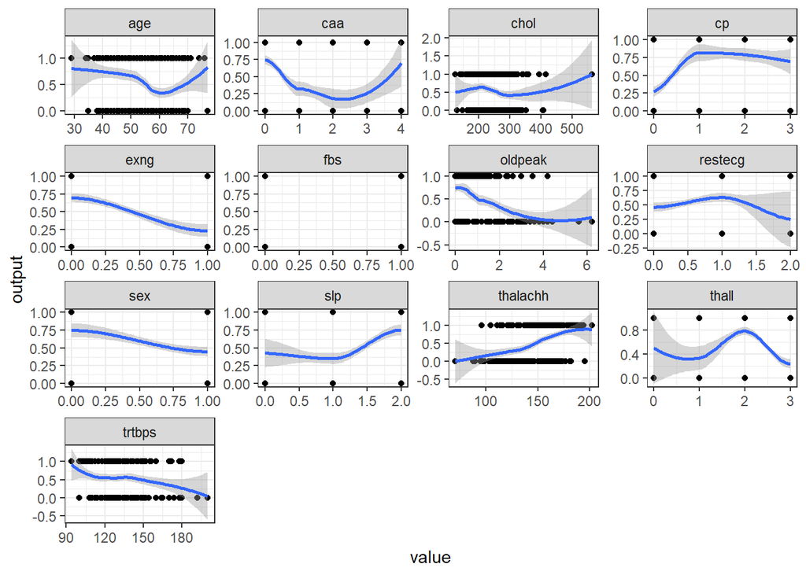

```r
# Graphs of all of the Variables
library("dplyr")
library("ggplot2")
library("tidyverse")
heart %>%
  gather(-output, key = "var", value = "value") %>%
  ggplot(aes(x = value, y = output)) +
  geom_point() +
  stat_smooth() +
  facet_wrap(~ var, scales = "free") +
  theme_bw()
```

## Step-wise Logistic Regression Model

Now that I have a sense of the data, it is time to begin the Logistic Regression modeling. First of all, the data needs to be partitioned into training and testing data sets. The code below divides the data into a training set (which contains 80% of the original data) and a testing set (containing the remaining 20% of the data).

```r
# Partition the data
set.seed(123)
trainingRow <- sample(1:nrow(heart), 0.8*nrow(heart))
heartTrain <- heart[trainingRow, ]
heartTest  <- heart[-trainingRow, ]
```

Now that the data has been partitioned, it is time to build the model. In this case, I will be using step-wise regression to build the model. This technique will go through all of the available variables and select the model that results in the lowest AIC value.

```r
# Step-wise regression model
library(MASS)
# Fit the model via step-wise regression
model <- glm(output ~., data = heartTrain, family = binomial) %>%
  stepAIC(trace = FALSE)
# Summarize the final selected model
summary(model)
```

```
##
## Call:
## glm(formula = output ~ sex + cp + trtbps + restecg + thalachh +
##     exng + oldpeak + caa + thall, family = binomial, data = heartTrain)
##
## Deviance Residuals:
##     Min       1Q   Median       3Q      Max
## -2.6067  -0.4420   0.1910   0.5717   2.3309
##
## Coefficients:
##             Estimate Std. Error z value Pr(>|z|)
## (Intercept)  3.19606    2.19394   1.457 0.145181
## sex         -1.32599    0.46075  -2.878 0.004003 **
## cp           0.77088    0.19431   3.967 7.27e-05 ***
## trtbps      -0.01947    0.01060  -1.837 0.066208 .
## restecg      0.76597    0.37861   2.023 0.043059 *
## thalachh     0.02238    0.01035   2.164 0.030487 *
## exng        -1.06707    0.44187  -2.415 0.015739 *
## oldpeak     -0.76245    0.21104  -3.613 0.000303 ***
## caa         -0.62944    0.19176  -3.282 0.001030 **
## thall       -1.05718    0.32926  -3.211 0.001324 **
## ---
## Signif. codes:  0 '***' 0.001 '**' 0.01 '*' 0.05 '.' 0.1 ' ' 1
##
## (Dispersion parameter for binomial family taken to be 1)
##
##     Null deviance: 333.48  on 241  degrees of freedom
## Residual deviance: 174.52  on 232  degrees of freedom
## AIC: 194.52
##
## Number of Fisher Scoring iterations: 6
```

## Making Predictions

Now that the best model has been chosen, it is time to make predictions.

```r
# Predictions
trainOutcome <- predict(model, heartTrain, type = 'response')

# If prediction is >= 0.5, classify as 1.
trainOutcome <- ifelse(trainOutcome >= 0.5, 1, 0)
# Add predictions to the training data set
heartTrain$Prediction <- trainOutcome
head(heartTrain)
```

```
##     age sex cp trtbps chol fbs restecg thalachh exng oldpeak slp caa thall
## 179  43   1  0    120  177   0       0      120    1     2.5   1   0     3
## 14   64   1  3    110  211   0       0      144    1     1.8   1   0     2
## 195  60   1  2    140  185   0       0      155    0     3.0   1   0     2
## 118  56   1  3    120  193   0       0      162    0     1.9   1   0     3
## 299  57   0  0    140  241   0       1      123    1     0.2   1   0     3
## 229  59   1  3    170  288   0       0      159    0     0.2   1   0     3
##     output Prediction
## 179      0          0
## 14       1          1
## 195      0          0
## 118      1          1
## 299      0          0
## 229      0          1
```

Now that the predictions have been made, it is time to check the accuracy of the model. To do this, I first build a contingency table to see the frequency of each prediction. From this, it is simple to calculate the accuracy of the model.

```r
# Contingency Table
contingencyTable <- as.data.frame(with(heartTrain, table(Prediction, output)))

# Accuracy
accuracy <- sum(contingencyTable[contingencyTable$Prediction == contingencyTable$output,]$Freq) /
  sum(contingencyTable$Freq)
contingencyTable
```

```
##   Prediction output Freq
## 1          0      0   86
## 2          1      0   24
## 3          0      1   11
## 4          1      1  121
```

```r
accuracy
```

```
## [1] 0.8553719
```

The model had a correct classification rate of 85.5%, which tells us that the model is performing very well. To check for overfitting, the model must now be run on the testing data set as well. The code below shows the predictions and accuracy for the test data.

```r
# Predictions
trainOutcome <- predict(model, heartTest, type = 'response')

# If prediction is >= 0.5, classify as 1.
trainOutcome <- ifelse(trainOutcome >= 0.5, 1, 0)

# Add predictions to the Test data set
heartTest$Prediction <- trainOutcome
head(heartTest)
```

```
##    age sex cp trtbps chol fbs restecg thalachh exng oldpeak slp caa thall
## 2   37   1  2    130  250   0       1      187    0     3.5   0   0     2
## 3   41   0  1    130  204   0       0      172    0     1.4   2   0     2
## 12  48   0  2    130  275   0       1      139    0     0.2   2   0     2
## 15  58   0  3    150  283   1       0      162    0     1.0   2   0     2
## 19  43   1  0    150  247   0       1      171    0     1.5   2   0     2
## 28  51   1  2    110  175   0       1      123    0     0.6   2   0     2
##    output Prediction
## 2       1          1
## 3       1          1
## 12      1          1
## 15      1          1
## 19      1          1
## 28      1          1
```

```r
# Contingency Table
contingencyTable <- as.data.frame(with(heartTest, table(Prediction, output)))

# Accuracy
accuracy <- sum(contingencyTable[contingencyTable$Prediction == contingencyTable$output,]$Freq) /
  sum(contingencyTable$Freq)
contingencyTable
```

```
##   Prediction output Freq
## 1          0      0   20
## 2          1      0    8
## 3          0      1    2
## 4          1      1   31
```

```r
accuracy
```

```
## [1] 0.8360656
```

As the testing data set had a very similar accuracy to training data, 83.6%, it does not appear that there is any risk of the data overfitting.

## Full Model Test Comparision

For Comparison’s sake, I also ran the logistic regression with all of the variables included. As we see from the result, the majority of the coefficients are insignificant and this model results in a higher AIC value.

```r
# Model with all of the variables
fullmodel <- glm(output ~., data = heartTrain, family = binomial)
summary(fullmodel)
```

```
##
## Call:
## glm(formula = output ~ ., family = binomial, data = heartTrain)
##
## Deviance Residuals:
##     Min       1Q   Median       3Q      Max
## -2.5075  -0.4226   0.2088   0.5732   2.4566
##
## Coefficients:
##              Estimate Std. Error z value Pr(>|z|)
## (Intercept)  3.700822   2.939154   1.259  0.20798
## age         -0.016799   0.025909  -0.648  0.51674
## sex         -1.356314   0.534573  -2.537  0.01117 *
## cp           0.620304   0.237454   2.612  0.00899 **
## trtbps      -0.014872   0.011517  -1.291  0.19662
## chol        -0.003294   0.004176  -0.789  0.43034
## fbs          0.143692   0.569976   0.252  0.80096
## restecg      0.555511   0.401931   1.382  0.16694
## thalachh     0.015514   0.012193   1.272  0.20326
## exng        -0.909059   0.481966  -1.886  0.05928 .
## oldpeak     -0.479361   0.300466  -1.595  0.11062
## slp          0.315880   0.417081   0.757  0.44884
## caa         -0.523733   0.234185  -2.236  0.02533 *
## thall       -0.812863   0.380466  -2.136  0.03264 *
## Prediction   0.790955   0.741686   1.066  0.28623
## ---
## Signif. codes:  0 '***' 0.001 '**' 0.01 '*' 0.05 '.' 0.1 ' ' 1
##
## (Dispersion parameter for binomial family taken to be 1)
##
##     Null deviance: 333.48  on 241  degrees of freedom
## Residual deviance: 171.92  on 227  degrees of freedom
## AIC: 201.92
##
## Number of Fisher Scoring iterations: 6
```

When predictions are made with the full model it results in the same accuracy as the step-wise model.

```r
# Predictions
Outcome <- predict(fullmodel, heartTrain, type = 'response')
Outcome <- ifelse(Outcome >= 0.5, 1, 0)
heartTrain$Pred <- Outcome

# Contingency Table
contingencyTable <- as.data.frame(with(heartTrain, table(Pred, output)))

# Accuracy
accuracy <- sum(contingencyTable[contingencyTable$Pred == contingencyTable$output,]$Freq) /
  sum(contingencyTable$Freq)
contingencyTable
```

```
##   Pred output Freq
## 1    0      0   86
## 2    1      0   24
## 3    0      1   11
## 4    1      1  121
```

```r
accuracy
```

```
## [1] 0.8553719
```

The Step-wise model gives the exact same accuracy while using less variables. A less complex model with the same or similar accuracy is preferable to a model that is far more complex.